```r
library(dplyr)
library(ggplot2)
library(readr)
library(NanoStringQCPro)
extradata = read_csv("rcc/160823 data on mm sent to core.csv")
metadata = data.frame(fname=list.files("rcc", pattern="*.RCC")) %>%
  tidyr::separate(fname, c("longname", "nanoid", "idstr"), sep="-", remove=FALSE) %>%
  tidyr::separate(idstr, c("block", "trash"), sep="_") %>%
  select(fname, block) %>% left_join(extradata, by="block")
metadata$sample = metadata$block
rccFiles = paste("rcc/", metadata$fname, sep="")
rlf = "rcc/NS_CancerImmune_C2929.rlf"
eset = newRccSet(rccFiles=rccFiles, rlf=rlf)
```

```
## Reading RCC files...
```

```
## checkRccSet() messages:
##   The following panel housekeeping genes were found: DNAJC14, FCF1, DHX16, ABCF1, EDC3, ZNF143, HDAC3, CNOT10, SAP130, AGK, POLR2A, AMMECR1L, SF3A3, COG7, TMUB2, ZC3H14, DDX50, G6PD, MRPS5, ALAS1, PPIA, SDHA, TBP, ZNF346, MTMR14, ERCC3, EIF2B4, CC2D1B, GUSB, TLK2, TUBB, TRIM39, NUBP1, USP39, PRPF…
```

```r
colnames(eset) = metadata$sample
# set seed to be reproduciblish
set.seed(12345)
```

# Imaging QC

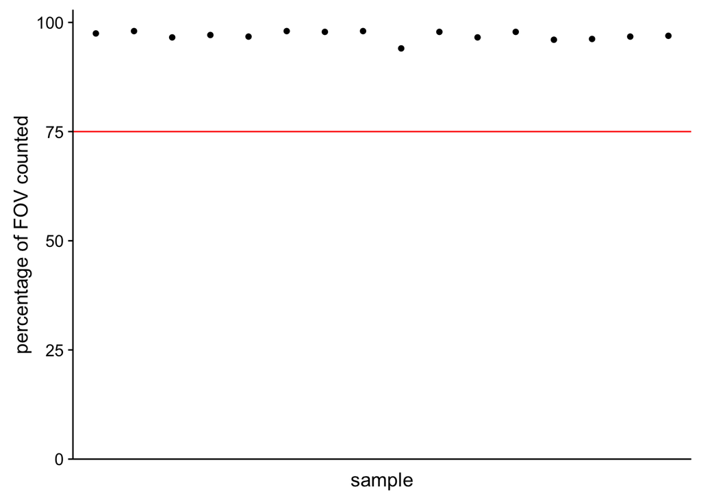

```r
plotFOV = function(eset, metadata) {
  pdat = pData(eset) %>%
    tibble::rownames_to_column() %>%
    left_join(metadata, by=c("rowname"="sample"))
  pdat$pcounted = pdat$FovCounted/pdat$FovCount * 100
  ggplot(pdat, aes(rowname, pcounted)) + geom_point() +
      theme(axis.text.x=element_blank(),
            axis.ticks.x=element_blank(),
            strip.text.x=element_text(size=8)) +
    scale_y_continuous(expand = c(0,0)) +
    expand_limits(y = c(0,1.05 * max(pdat$pcounted))) +
    ylab("percentage of FOV counted") + xlab("sample") +
    geom_hline(yintercept=75, color="red")
}
plotFOV(eset, metadata)
```

# Binding density

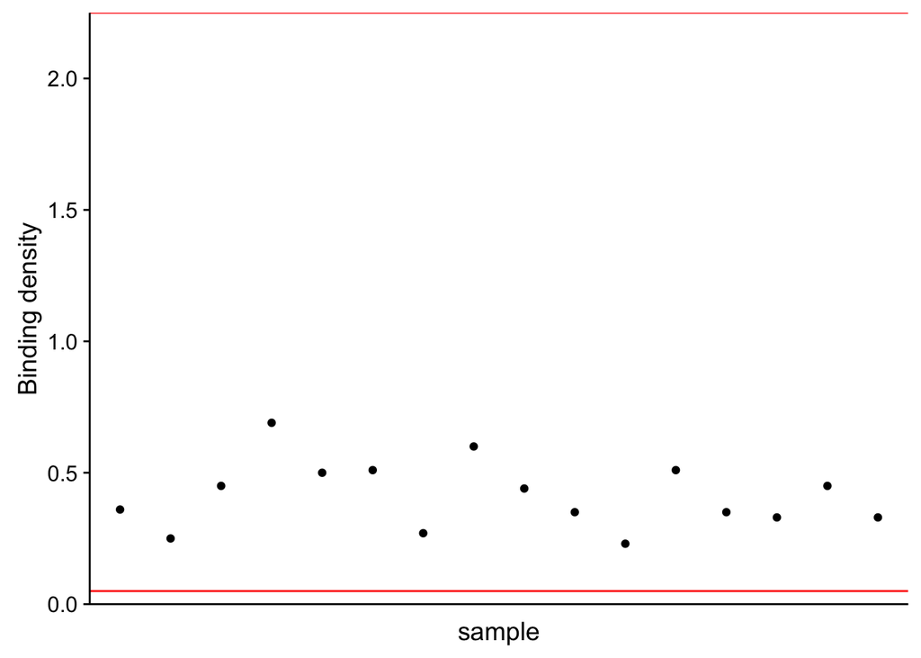

```r
plotBD = function(eset, metadata) {
  pdat = pData(eset) %>%
    tibble::rownames_to_column() %>%
    left_join(metadata, by=c("rowname"="sample"))
  pdat$pcounted = pdat$FovCounted/pdat$FovCount * 100
  ggplot(pdat, aes(rowname, BindingDensity)) + geom_point() +
      theme(axis.text.x=element_blank(),
            axis.ticks.x=element_blank(),
            strip.text.x=element_text(size=8)) +
    scale_y_continuous(expand = c(0,0)) +
    expand_limits(y = c(0,1.05 * max(pdat$BindingDensity))) +
    ylab("Binding density") + xlab("sample") +
    geom_hline(yintercept=0.05, color="red") +
    geom_hline(yintercept=2.25, color="red")
}
plotBD(eset, metadata)
```

# Total counts vs mRNA detected

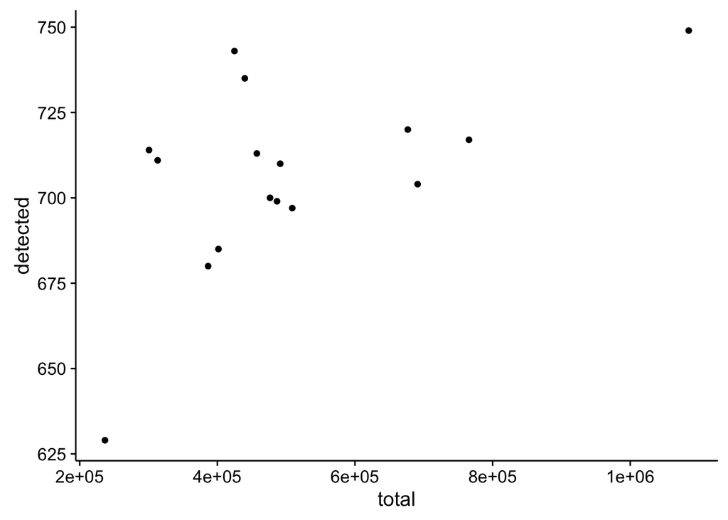

```r
plotComplexity = function(eset, metadata) {
  counts = exprs(eset)
  endocounts = counts[grepl("Endo", rownames(counts)),]
  cdf = data.frame(total=colSums(counts), detected=colSums(counts > 10))
  rownames(cdf) = colnames(counts)
  cdf$sample = rownames(cdf)
  cdf = cdf %>% left_join(metadata, by="sample")
  ggplot(cdf, aes(total, detected)) + geom_point()
}
plotComplexity(eset, metadata)
```

```r
library(ggplot2)
library(dplyr)
library(cowplot)
is_positive = function(column) {
  return(grepl("Pos", column))
}
is_negative = function(column) {
  return(grepl("Neg", column))
}
is_spikein = function(column) {
  return(grepl("Spike", column))
}
is_ligation = function(column) {
  return(grepl("Ligati", column))
}
is_housekeeping = function(column) {
  return(grepl("Housekee", column))
}
is_prior = function(column) {
  return(grepl("miR-159", column) | grepl("miR-248", column) |
         grepl("miR-254", column))
}

extract_pred = function(eset, predicate, counts=FALSE) {
  if(!counts) {
    counts = data.frame(exprs(eset))
  } else {
    counts = eset
    }
  toplot = counts[predicate(rownames(counts)),] %>%
    tibble::rownames_to_column() %>%
    tidyr::gather("sample", "count", -rowname)
  colnames(toplot) = c("spot", "sample", "count")
  toplot = toplot %>% left_join(metadata, by="sample")
  return(toplot)
}
spotbarplot = function(toplot) {
  ggplot(toplot,
        aes(sample, count)) + geom_bar(stat='identity') +
    facet_wrap(~spot) +
    theme(axis.text.x = element_blank(),
          text = element_text(size=8))
}
spotboxplot = function(toplot) {
  ggplot(toplot,
        aes(linehypo, count)) + geom_boxplot() +
    facet_wrap(~spot) +
    theme(axis.text.x = element_text(angle = 90, hjust = 1))
}
```

# Positive controls

Below we look at the R^2 correlation between the expected positive control concentrations and the observed concentrations for each sample.

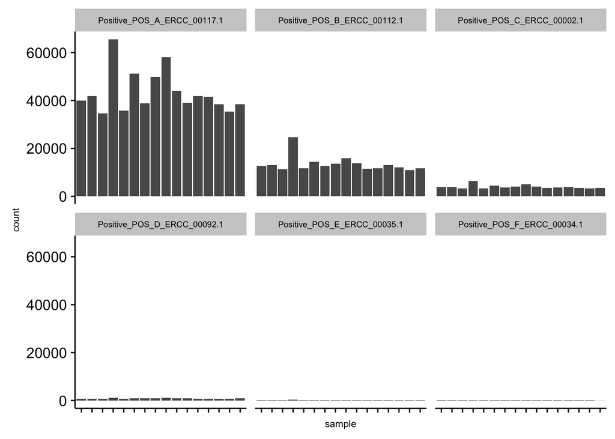

```r
spotbarplot(extract_pred(eset, is_positive))
```

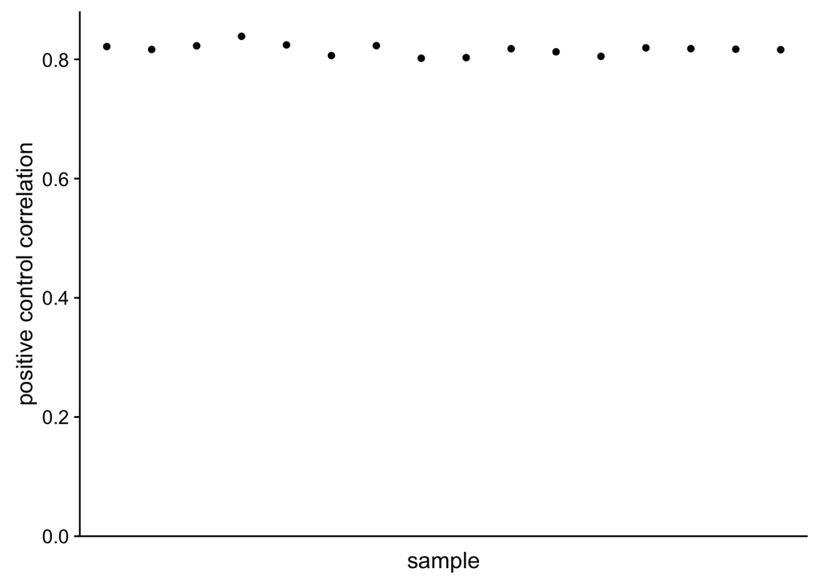

```r
posR2 = function(eset) {
  pcdf = data.frame(concentration=log2(c(128, 32, 8, 2, 0.5, 0.125)),
                    GeneName=paste("POS", c("A", "B", "C", "D", "E", "F"), sep="_"))
  pccounts = subset(exprs(eset), grepl("Positive_POS", rownames(exprs(eset))))
  pccounts = pccounts[sort(rownames(pccounts)),]
  rownames(pccounts) = pcdf$GeneName
  corsamples = data.frame(correlation=apply(pccounts, 2,
                                            function(x) cor(x, pcdf$concentration)),
                          sample=colnames(pccounts)) %>%
    left_join(metadata, by="sample")
  p = ggplot(corsamples, aes(sample, correlation)) + geom_point() +
      theme(axis.text.x=element_blank(),
            axis.ticks.x=element_blank(),
            strip.text.x=element_text(size=8)) +
    scale_y_continuous(expand = c(0,0)) +
    expand_limits(y = c(0,1.05 * max(corsamples$correlation))) +
    ylab("positive control correlation") +
    xlab("sample")
  print(p)
  return(corsamples)
}
corsamples = posR2(eset)
```

# Negative controls

We can see some samples have a higher negative control count than the other samples.

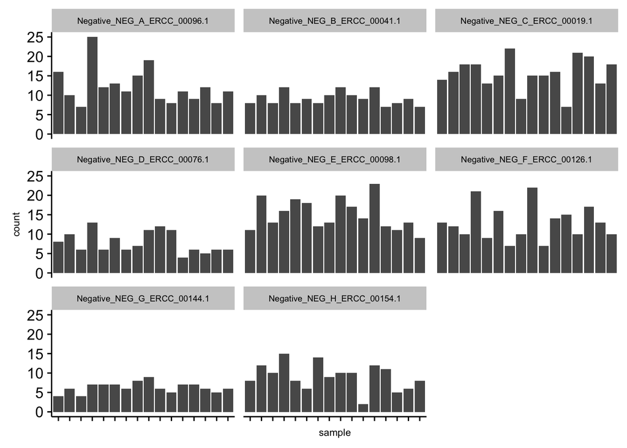

```r
spotbarplot(extract_pred(eset, is_negative))
```

# Housekeeping

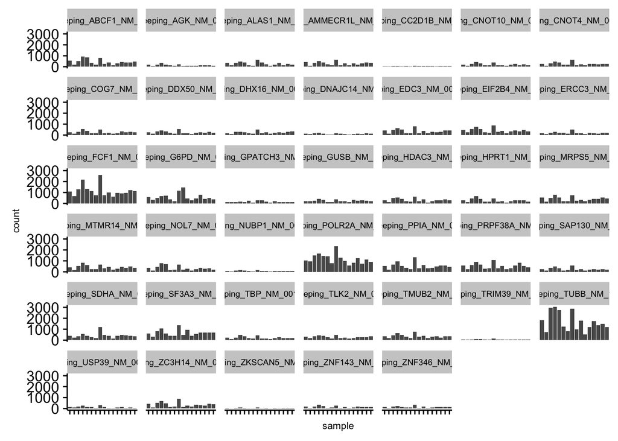

```r
spotbarplot(extract_pred(eset, is_housekeeping))
```

Here we calculate the geometric means of the housekeeping genes for each sample, and use that to normalize the counts.

```r
geo_housekeeping = function(eset) {
  counts = exprs(eset)
  hk = counts[grepl("Housekeeping", rownames(counts)),]
  geoMeans = apply(hk, 2, function(col) exp(mean(log(col[col != 0]))))
  return(geoMeans)}
normFactor = function(eset) {
  geoMeans = geo_housekeeping(eset)
  nf = mean(geoMeans) / geoMeans
  return(nf)}
metadata$normfactor = normFactor(eset)
```

# Drop counts

```r
drop_unusable = function(counts) {
  drop = is_spikein(rownames(counts))
  drop = drop | is_positive(rownames(counts))
  drop = drop | is_housekeeping(rownames(counts))
  drop = drop | is_ligation(rownames(counts))
  keep = counts[!drop,]
  keep = keep[, !grepl("Blank", colnames(keep))]
  return(keep)
}
counts = exprs(eset)
counts = drop_unusable(counts)
nfloor = 30
counts = counts[(rowSums(counts) > nfloor) < (0.2 * ncol(counts)),]
```

# Differential expression

```r
library(edgeR)
library(limma)
library(vsn)
design = model.matrix(~metadata$thickness+metadata$progressing)
```

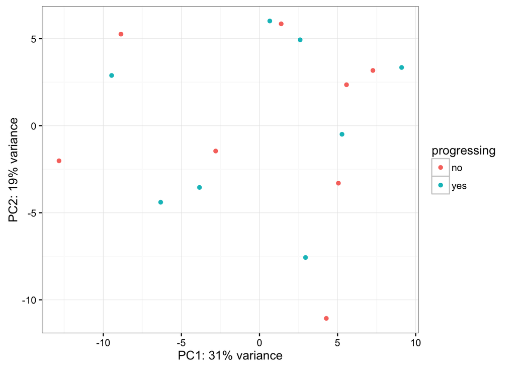

```r
vst <- function(countdata){
  library(DESeq)
  condition <- factor(rep("Tumour", ncol(countdata)))
  countdata <- newCountDataSet(countdata,condition )
  countdata <- estimateSizeFactors( countdata )
  cdsBlind <- DESeq::estimateDispersions( countdata, method="blind")
  vstdata <- varianceStabilizingTransformation( cdsBlind )
  return(exprs(vstdata))
}
pca_loadings = function(object, ntop=500) {
  object = as.matrix(object)
  rv <- matrixStats::rowVars(object)
  select <- order(rv, decreasing = TRUE)[seq_len(min(ntop,
      length(rv)))]
  pca <- prcomp(t(object[select,]))
  percentVar <- pca$sdev^2/sum(pca$sdev^2)
  names(percentVar) = colnames(pca$x)
  pca$percentVar = percentVar
  return(pca)}
oldcounts = counts
vstdata = vst(counts)
pc = pca_loadings(vstdata, 50)
comps = data.frame(pc$x)
comps$Name = rownames(comps)
library(dplyr)
comps = comps %>% left_join(metadata, by=c("Name"="sample"))
pca_plot = function(comps, nc1, nc2, colorby) {
   c1str = paste0("PC", nc1)
   c2str = paste0("PC", nc2)
  ggplot(comps, aes_string(c1str, c2str, color=colorby)) +
    geom_point() + theme_bw() +
    xlab(paste0(c1str, ": ", round(pc$percentVar[nc1] * 100), "% variance")) +
    ylab(paste0(c2str, ": ", round(pc$percentVar[nc2] * 100), "% variance"))
  }
pca_plot(comps, 1, 2, "progressing")
```

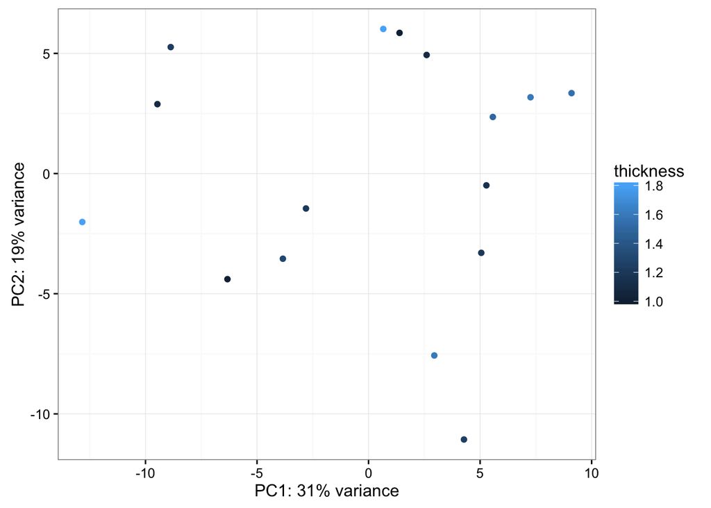

```r
pca_plot(comps, 1, 2, "thickness")
```

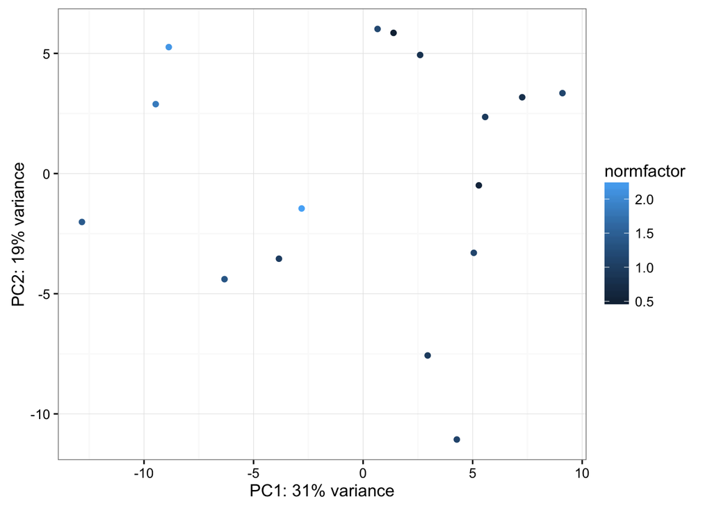

```r
pca_plot(comps, 1, 2, "normfactor")
```

# Differential expression

Here we do it two different ways. The first normalizing the counts by the normalization factor calculated from the geometric means of the housekeeping genes, the second we just use the raw counts.

## Normalized by the housekeeping genes

```r
ncounts = counts * metadata$normfactor
dge = DGEList(ncounts)
v = voom(dge, design)
fit = lmFit(v,design)
fit = eBayes(fit)
prog = topTable(fit, coef=3, number=Inf) %>%
  tibble::rownames_to_column() %>%
  arrange(adj.P.Val)
write.table(prog, file="progressive-hk.csv", col.names=TRUE, quote=FALSE,
            row.names=FALSE, sep=",")
thick = topTable(fit, coef=2, number=Inf) %>%
  tibble::rownames_to_column() %>%
  arrange(adj.P.Val)
write.table(thick, file="thickness-hk.csv", col.names=TRUE, quote=FALSE,
            row.names=FALSE, sep=",")
```

## Not normalized by the housekeeping genes

```r
dge = DGEList(counts)
v = voom(dge, design)
fit = lmFit(v,design)
fit = eBayes(fit)
prog = topTable(fit, coef=3, number=Inf) %>%
  tibble::rownames_to_column() %>%
  arrange(adj.P.Val)
write.table(prog, file="progressive.csv", col.names=TRUE, quote=FALSE,
            row.names=FALSE, sep=",")
thick = topTable(fit, coef=2, number=Inf) %>%
  tibble::rownames_to_column() %>%
  arrange(adj.P.Val)
write.table(thick, file="thickness.csv", col.names=TRUE, quote=FALSE,
            row.names=FALSE, sep=",")
```

# Summary

These samples are extremely variable– we normalized the samples and corrected for thickness and still can’t find anything significant. We don’t see any clear clustering on the PCA plots by either thickness or progressive status, so these samples have too much variability to call any differences.

That being said it might be worthwhile to take the output and ran by unadjusted pvalue or logFC and see if any of those hits look interesting, even if they don’t reach significance.